# Exploratory Data Analysis in R

DataCamp - Andrew Bray

12/16/2020

## Exploring categorical data

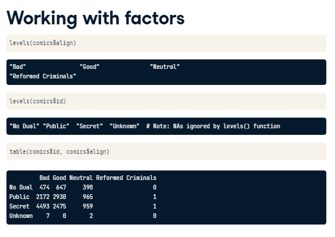

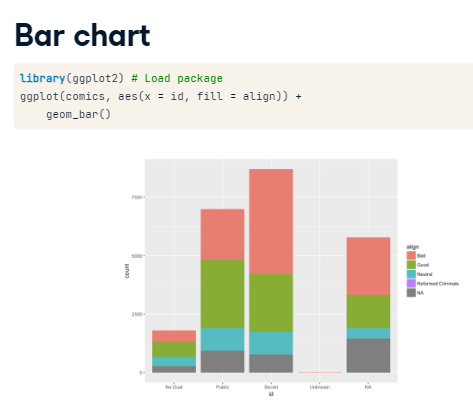

**Contingency table review**

In this chapter you’ll continue working with the `comics` dataset introduced in the video. This is a collection of characteristics on all of the superheroes created by Marvel and DC comics in the last 80 years.

Let’s start by creating a contingency table, which is a useful way to represent the total counts of observations that fall into each combination of the levels of categorical variables.

```r
library(readr)
comics <- read_csv("_data/comics.csv", col_types = "ffffffffiff")

# Print the first rows of the data
comics
```

```
## # A tibble: 23,272 x 11
##    name  id    align eye   hair  gender gsm   alive appearances first_appear
##    <fct> <fct> <fct> <fct> <fct> <fct>  <fct> <fct>       <int> <fct>
##  1 "Spi~ Secr~ Good  Haze~ Brow~ Male   <NA>  Livi~        4043 Aug-62
##  2 "Cap~ Publ~ Good  Blue~ Whit~ Male   <NA>  Livi~        3360 Mar-41
##  3 "Wol~ Publ~ Neut~ Blue~ Blac~ Male   <NA>  Livi~        3061 Oct-74
##  4 "Iro~ Publ~ Good  Blue~ Blac~ Male   <NA>  Livi~        2961 Mar-63
##  5 "Tho~ No D~ Good  Blue~ Blon~ Male   <NA>  Livi~        2258 Nov-50
##  6 "Ben~ Publ~ Good  Blue~ No H~ Male   <NA>  Livi~        2255 Nov-61
##  7 "Ree~ Publ~ Good  Brow~ Brow~ Male   <NA>  Livi~        2072 Nov-61
##  8 "Hul~ Publ~ Good  Brow~ Brow~ Male   <NA>  Livi~        2017 May-62
##  9 "Sco~ Publ~ Neut~ Brow~ Brow~ Male   <NA>  Livi~        1955 Sep-63
## 10 "Jon~ Publ~ Good  Blue~ Blon~ Male   <NA>  Livi~        1934 Nov-61
## # ... with 23,262 more rows, and 1 more variable: publisher <fct>
```

```r
# Check levels of align
levels(comics$align)
```

```
## [1] "Good"               "Neutral"            "Bad"
## [4] "Reformed Criminals"
```

```r
# Check the levels of gender
levels(comics$gender)
```

```
## [1] "Male"   "Female" "Other"
```

```r
# Create a 2-way contingency table
table(comics$align, comics$gender)
```

```
##
##                      Male Female Other
##   Good               4809   2490    17
##   Neutral            1799    836    17
##   Bad                7561   1573    32
##   Reformed Criminals    2      1     0
```

**Dropping levels**

The contingency table from the last exercise revealed that there are some levels that have very low counts. To simplify the analysis, it often helps to drop such levels.

In R, this requires two steps: first filtering out any rows with the levels that have very low counts, then removing these levels from the factor variable with `droplevels()`. This is because the `droplevels()` function would keep levels that have just 1 or 2 counts; it only drops levels that don’t exist in a dataset.

```r
# Load dplyr
library(dplyr)
# Print tab
tab <- table(comics$align, comics$gender)
tab
```

```
##
##                      Male Female Other
##   Good               4809   2490    17
##   Neutral            1799    836    17
##   Bad                7561   1573    32
##   Reformed Criminals    2      1     0
```

```r
# Remove align level
comics_filtered <- comics %>%
  filter(align != "Reformed Criminals") %>%
  droplevels()

# See the result
comics_filtered
```

```
## # A tibble: 19,856 x 11
##    name  id    align eye   hair  gender gsm   alive appearances first_appear
##    <fct> <fct> <fct> <fct> <fct> <fct>  <fct> <fct>       <int> <fct>
##  1 "Spi~ Secr~ Good  Haze~ Brow~ Male   <NA>  Livi~        4043 Aug-62
##  2 "Cap~ Publ~ Good  Blue~ Whit~ Male   <NA>  Livi~        3360 Mar-41
##  3 "Wol~ Publ~ Neut~ Blue~ Blac~ Male   <NA>  Livi~        3061 Oct-74
##  4 "Iro~ Publ~ Good  Blue~ Blac~ Male   <NA>  Livi~        2961 Mar-63
##  5 "Tho~ No D~ Good  Blue~ Blon~ Male   <NA>  Livi~        2258 Nov-50
##  6 "Ben~ Publ~ Good  Blue~ No H~ Male   <NA>  Livi~        2255 Nov-61
##  7 "Ree~ Publ~ Good  Brow~ Brow~ Male   <NA>  Livi~        2072 Nov-61
##  8 "Hul~ Publ~ Good  Brow~ Brow~ Male   <NA>  Livi~        2017 May-62
##  9 "Sco~ Publ~ Neut~ Brow~ Brow~ Male   <NA>  Livi~        1955 Sep-63
## 10 "Jon~ Publ~ Good  Blue~ Blon~ Male   <NA>  Livi~        1934 Nov-61
## # ... with 19,846 more rows, and 1 more variable: publisher <fct>
```

**Side-by-side barcharts**

While a contingency table represents the counts numerically, it’s often more useful to represent them graphically.

Here you’ll construct two side-by-side barcharts of the `comics` data. This shows that there can often be two or more options for presenting the same data. Passing the argument`position = "dodge"` to `geom_bar()` says that you want a side-by-side (i.e. not stacked) barchart.

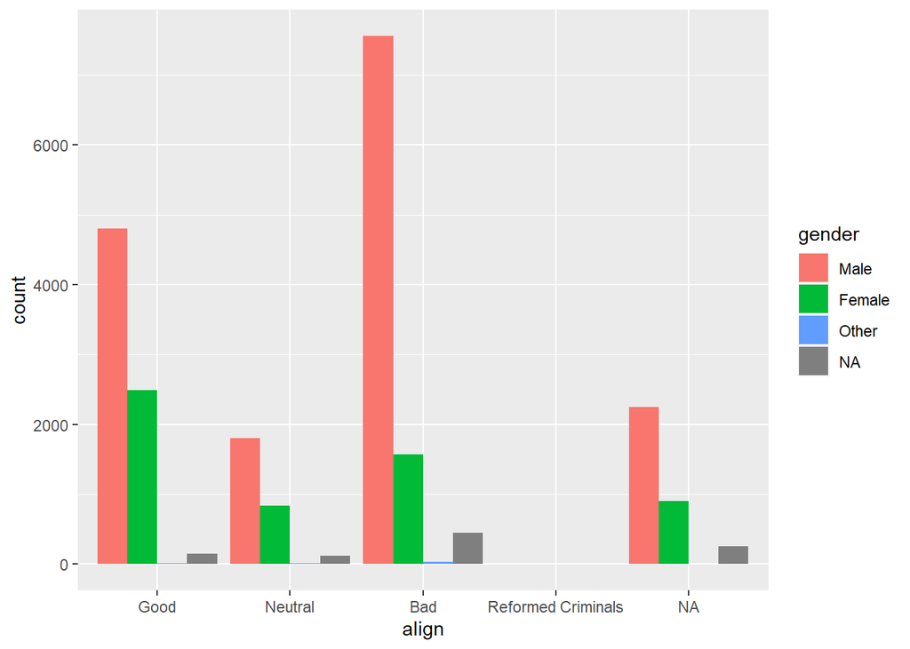

```r
# Load ggplot2
library(ggplot2)

# Create side-by-side barchart of gender by alignment
ggplot(comics, aes(x = align, fill = gender)) +
  geom_bar(position = "dodge")
```

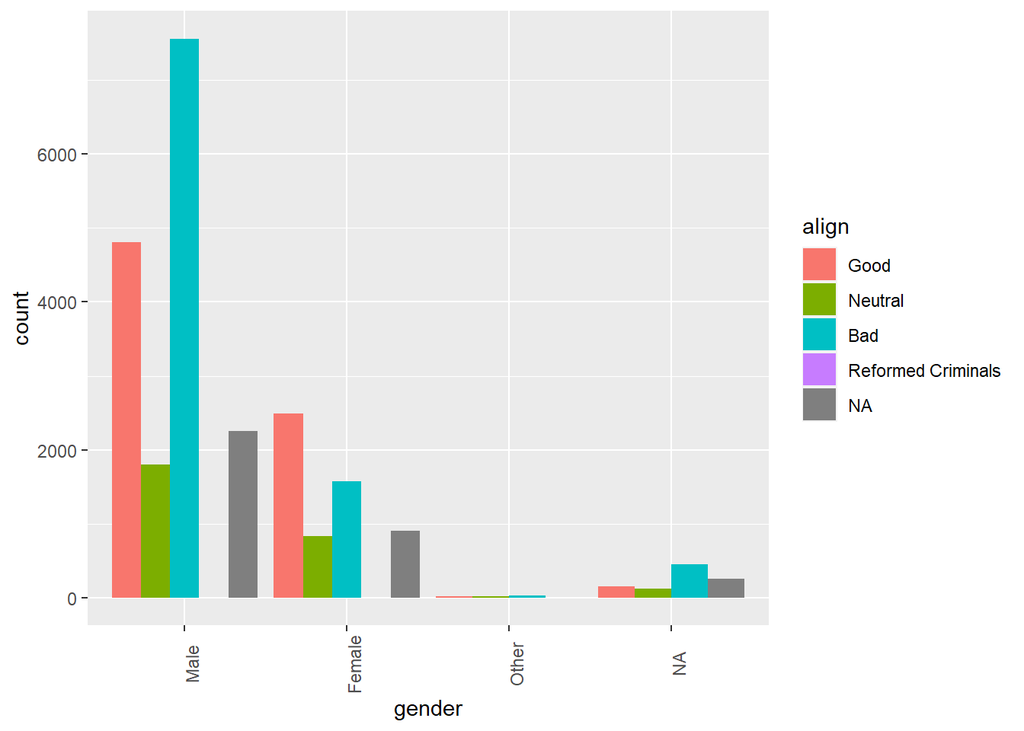

```r
# Create side-by-side barchart of alignment by gender
ggplot(comics, aes(x = gender, fill = align)) +
  geom_bar(position = "dodge") +
  theme(axis.text.x = element_text(angle = 90))
```

## Counts vs. proportions

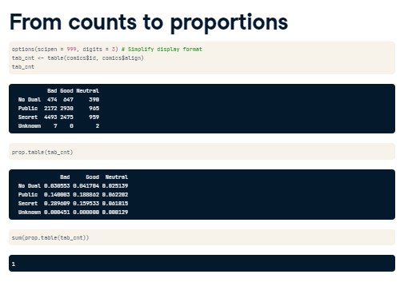

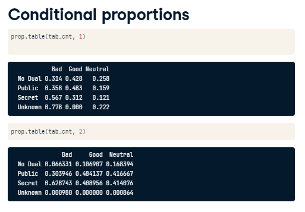

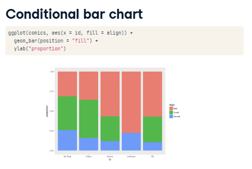

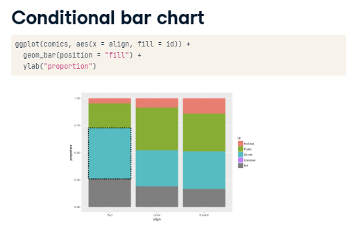

**Q:** Approximately what proportion of all female characters are good?

```r
tab <- table(comics$align, comics$gender)
options(scipen = 999, digits = 3) # Print fewer digits
prop.table(tab)     # Joint proportions
```

```
##
##                           Male    Female     Other
##   Good               0.2512933 0.1301144 0.0008883
##   Neutral            0.0940064 0.0436850 0.0008883
##   Bad                0.3950985 0.0821968 0.0016722
##   Reformed Criminals 0.0001045 0.0000523 0.0000000
```

```r
prop.table(tab, 2)  # Conditional on columns
```

```
##
##                          Male   Female    Other
##   Good               0.339355 0.508163 0.257576
##   Neutral            0.126949 0.170612 0.257576
##   Bad                0.533554 0.321020 0.484848
##   Reformed Criminals 0.000141 0.000204 0.000000
```

**A:** 51%

Nice! To answer this question, you needed to look at how `align` was distributed *within* each `gender`. That is, you wanted to *condition* on the `gender` variable.

**Counts vs. proportions (2)**

Bar charts can tell dramatically different stories depending on whether they represent counts or proportions and, if proportions, what the proportions are conditioned on. To demonstrate this difference, you’ll construct two barcharts in this exercise: one of counts and one of proportions.

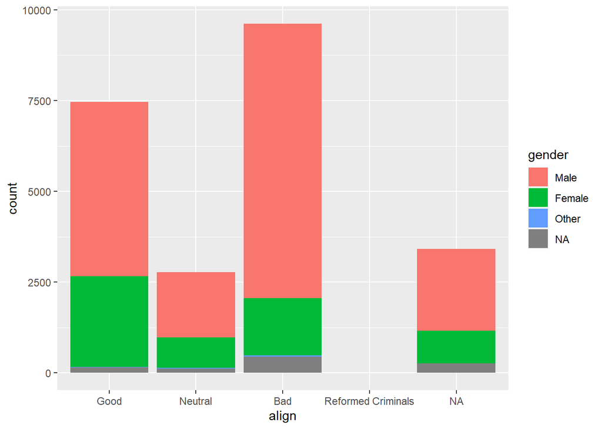

```r
# Plot of gender by align
ggplot(comics, aes(x = align, fill = gender)) +
  geom_bar()
```

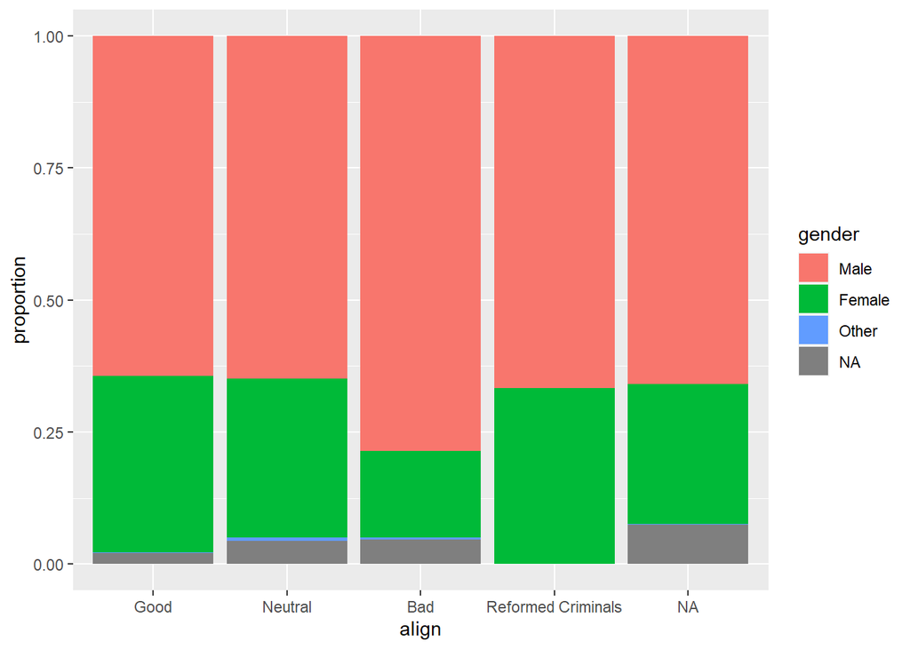

```r
# Plot proportion of gender, conditional on align
ggplot(comics, aes(x = align, fill = gender)) +
  geom_bar(position = "fill") +
  ylab("proportion")
```

Excellent work! By adding `position = "fill"` to `geom_bar()`, you are saying you want the bars to fill the entire height of the plotting window, thus displaying proportions and not raw counts.

## Distribution of one variable

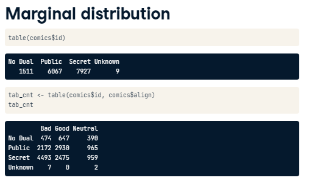

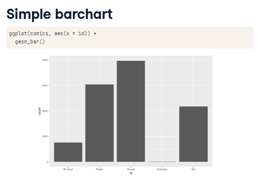

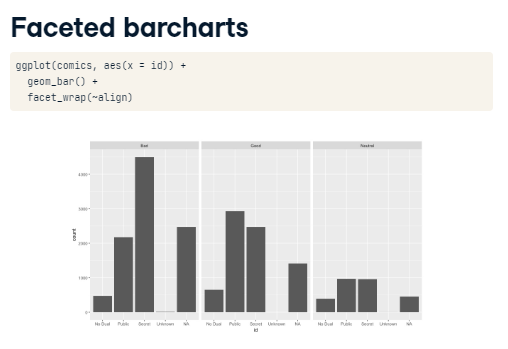

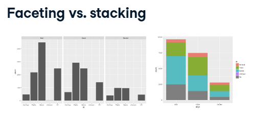

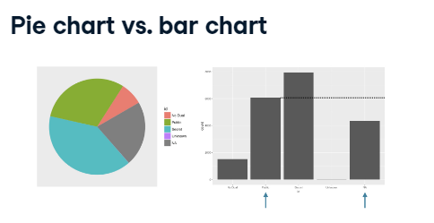

**Marginal barchart**

If you are interested in the distribution of alignment of *all* superheroes, it makes sense to construct a barchart for just that single variable.

You can improve the interpretability of the plot, though, by implementing some sensible ordering. Superheroes that are `"Neutral"` show an alignment between `"Good"` and `"Bad"`, so it makes sense to put that bar in the middle.

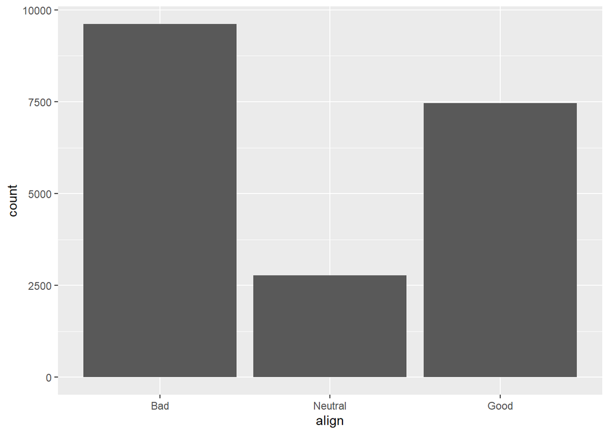

```r
# Change the order of the levels in align
comics_filtered$align <- factor(comics_filtered$align,
                       levels = c("Bad", "Neutral", "Good"))

# Create plot of align
ggplot(comics_filtered, aes(x = align)) +
  geom_bar()
```

**Conditional barchart**

Now, if you want to break down the distribution of alignment based on gender, you’re looking for conditional distributions.

You could make these by creating multiple filtered datasets (one for each gender) or by faceting the plot of alignment based on gender. As a point of comparison, we’ve provided your plot of the marginal distribution of alignment from the last exercise.

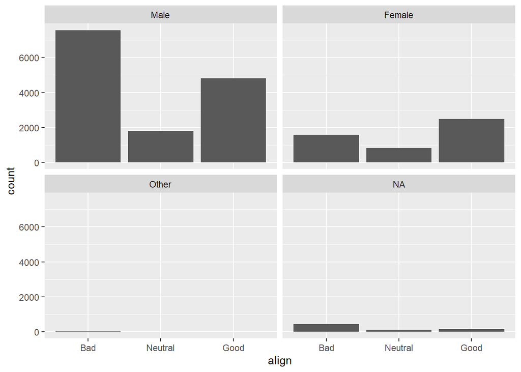

```r
# Plot of alignment broken down by gender
ggplot(comics_filtered, aes(x = align)) +
  geom_bar() +
  facet_wrap(~ gender)
```

**Improve piechart**

The piechart is a very common way to represent the distribution of a single categorical variable, but they can be more difficult to interpret than barcharts.

This is a piechart of a dataset called `pies` that contains the favorite pie flavors of 98 people. Improve the representation of these data by constructing a `barchart` that is ordered in descending order of count.

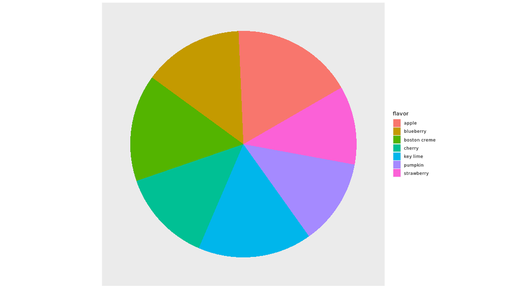

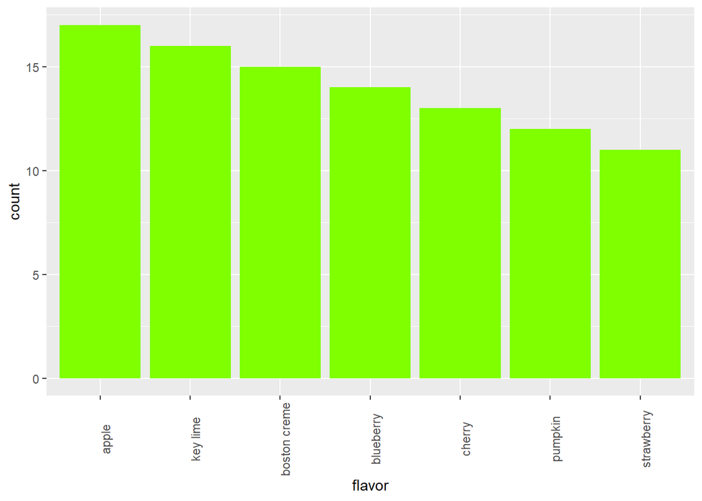

```r
pies <- data.frame(flavors = as.factor(rep(c("apple", "blueberry", "boston creme", "cherry", "key lime", "pumpkin", "strawberry"), times = c(17, 14, 15, 13, 16, 12, 11))))

# Put levels of flavor in descending order
lev <- c("apple", "key lime", "boston creme", "blueberry", "cherry", "pumpkin", "strawberry")
pies$flavor <- factor(pies$flavor, levels = lev)

# Create barchart of flavor
ggplot(pies, aes(x = flavor)) +
  geom_bar(fill = "chartreuse") +
  theme(axis.text.x = element_text(angle = 90))
```

```r
# Alternative solution to finding levels
# lev <- unlist(select(arrange(cnt, desc(n)), flavor))
```

## Exploring numerical data

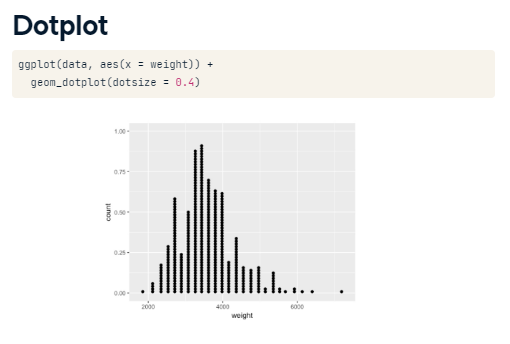

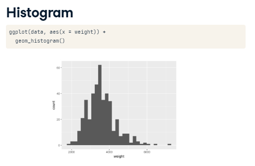

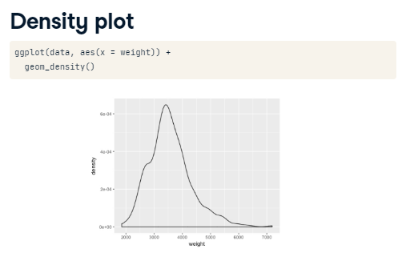

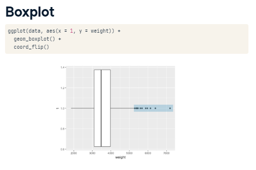

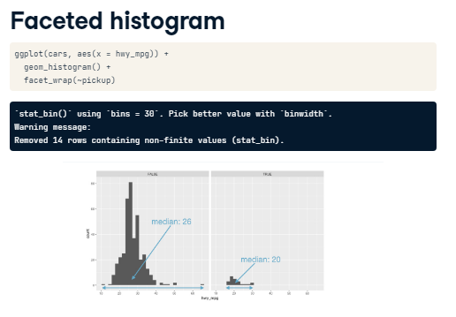

**Faceted histogram**

In this chapter, you’ll be working with the `cars` dataset, which records characteristics on all of the new models of cars for sale in the US in a certain year. You will investigate the distribution of mileage across a categorial variable, but before you get there, you’ll want to familiarize yourself with the dataset.

```r
cars <- read.csv("_data/cars04.csv", stringsAsFactors = TRUE)

# Load package
library(ggplot2)

# Learn data structure
str(cars)
```

```
## 'data.frame':    428 obs. of  19 variables:
##  $ name       : Factor w/ 425 levels "Acura 3.5 RL 4dr",..: 66 67 68 69 70 114 115 133 129 130 ...
##  $ sports_car : logi  FALSE FALSE FALSE FALSE FALSE FALSE ...
##  $ suv        : logi  FALSE FALSE FALSE FALSE FALSE FALSE ...
##  $ wagon      : logi  FALSE FALSE FALSE FALSE FALSE FALSE ...
##  $ minivan    : logi  FALSE FALSE FALSE FALSE FALSE FALSE ...
##  $ pickup     : logi  FALSE FALSE FALSE FALSE FALSE FALSE ...
##  $ all_wheel  : logi  FALSE FALSE FALSE FALSE FALSE FALSE ...
##  $ rear_wheel : logi  FALSE FALSE FALSE FALSE FALSE FALSE ...
##  $ msrp       : int  11690 12585 14610 14810 16385 13670 15040 13270 13730 15460 ...
##  $ dealer_cost: int  10965 11802 13697 13884 15357 12849 14086 12482 12906 14496 ...
##  $ eng_size   : num  1.6 1.6 2.2 2.2 2.2 2 2 2 2 2 ...
##  $ ncyl       : int  4 4 4 4 4 4 4 4 4 4 ...
##  $ horsepwr   : int  103 103 140 140 140 132 132 130 110 130 ...
##  $ city_mpg   : int  28 28 26 26 26 29 29 26 27 26 ...
##  $ hwy_mpg    : int  34 34 37 37 37 36 36 33 36 33 ...
##  $ weight     : int  2370 2348 2617 2676 2617 2581 2626 2612 2606 2606 ...
##  $ wheel_base : int  98 98 104 104 104 105 105 103 103 103 ...
##  $ length     : int  167 153 183 183 183 174 174 168 168 168 ...
##  $ width      : int  66 66 69 68 69 67 67 67 67 67 ...
```

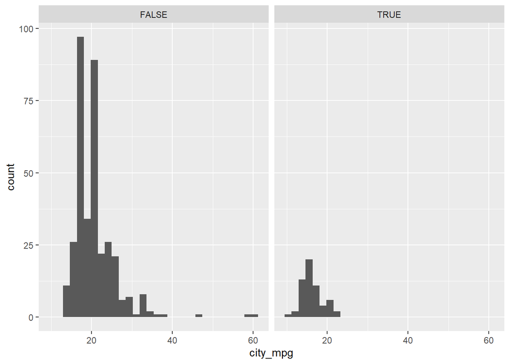

```r
# Create faceted histogram
ggplot(cars, aes(x = city_mpg)) +
  geom_histogram() +
  facet_wrap(~ suv)
```

In this exercise, you faceted by the `suv` variable, but it’s important to note that you can facet a plot by any categorical variable using `facet_wrap()`. Nice job!

**Boxplots and density plots**

The mileage of a car tends to be associated with the size of its engine (as measured by the number of cylinders). To explore the relationship between these two variables, you could stick to using histograms, but in this exercise you’ll try your hand at two alternatives: the box plot and the density plot.

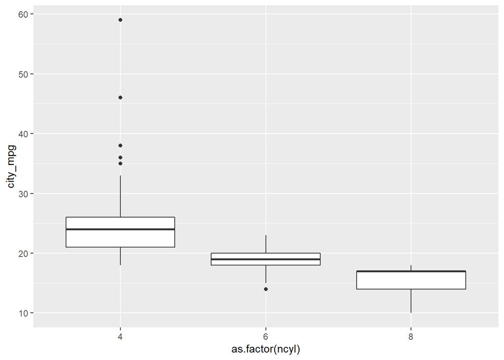

```r
# Filter cars with 4, 6, 8 cylinders
common_cyl <- filter(cars, ncyl %in% c(4, 6, 8))

# Create box plots of city mpg by ncyl
ggplot(common_cyl, aes(x = as.factor(ncyl), y = city_mpg)) +
  geom_boxplot()
```

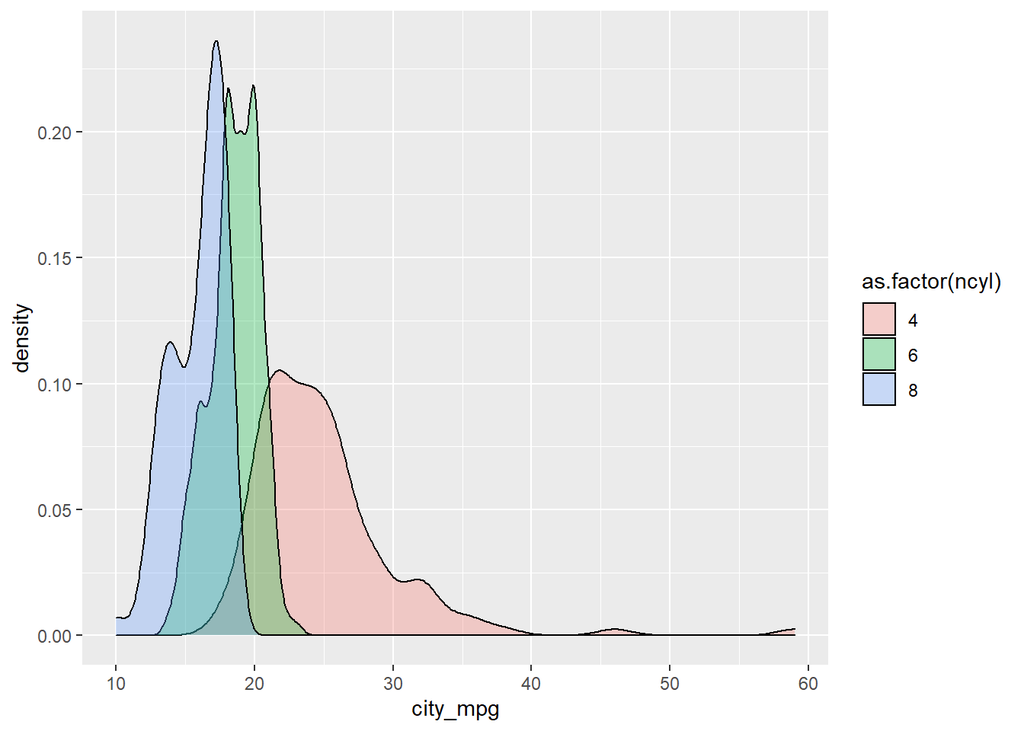

```r
# Create overlaid density plots for same data
ggplot(common_cyl, aes(x = city_mpg, fill = as.factor(ncyl))) +
  geom_density(alpha = .3)
```

## Distribution of one variable

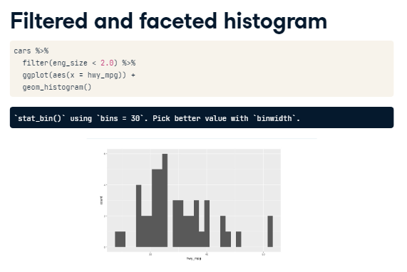

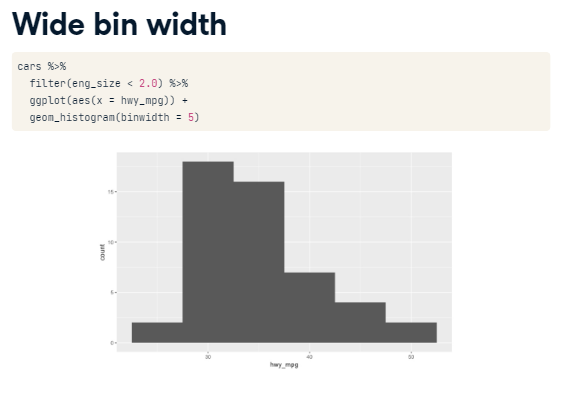

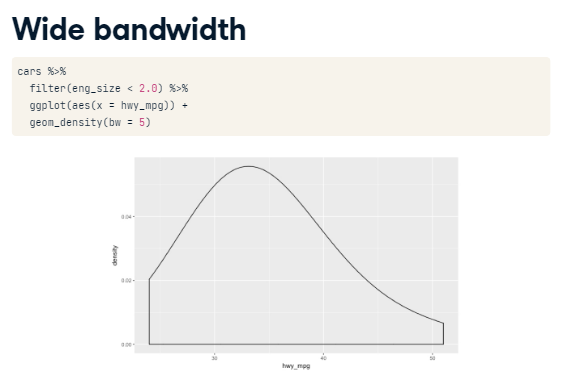

**Marginal and conditional histograms**

Now, turn your attention to a new variable: `horsepwr`. The goal is to get a sense of the marginal distribution of this variable and then compare it to the distribution of horsepower conditional on the price of the car being less than $25,000.

You’ll be making two plots using the “data pipeline” paradigm, where you start with the raw data and end with the plot.

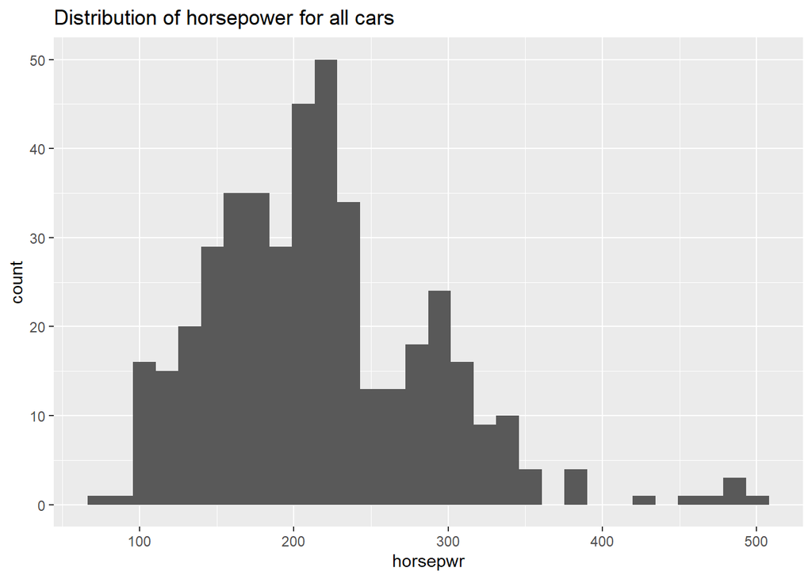

```r
# Create hist of horsepwr
cars %>%
  ggplot(aes(x = horsepwr)) +
  geom_histogram() +
  ggtitle("Distribution of horsepower for all cars")
```

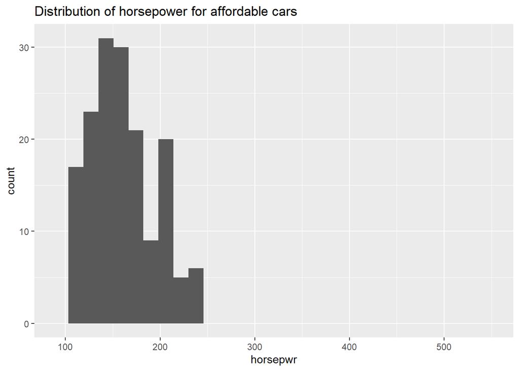

```r
# Create hist of horsepwr for affordable cars
cars %>%
  filter(msrp < 25000) %>%
  ggplot(aes(x = horsepwr)) +
  geom_histogram() +
  xlim(c(90, 550)) +
  ggtitle("Distribution of horsepower for affordable cars")
```

**Three binwidths**